# Molecular Marker Assisted Plant Breeding

Linkage Mapping

Felipe Ferrão

University of Florida

**Objectives:**

- 60 minutes of hands-on
- Introduction to Linkage Mapping for BC populations
- Use of `Onemap` R package

**Extra information**

- [HOS 6236 – Website](https://lfelipe-ferrao.github.io/class/mas/)
- About the [author](https://lfelipe-ferrao.github.io/)
- About the [UF/IFAS Plant Breeding](https://programs.ifas.ufl.edu/plant-breeding/)

# Introduction

In this tutorial, we will demonstrate the basic steps involved in designing a linkage map. There are several well-established pipelines and resources available online that provide detailed instructions for building high-quality genetic maps. Some of the most commonly used software tools include R/qtl, OneMap, and MapPoly, all of which are R packages tailored for different types of populations and ploidy levels.

Here, our focus is on a simulated dataset, which allows us to explore the fundamental concepts behind map construction without the complexity of real-world data. This tutorial is intended as a conceptual introduction; for a deeper, more practical understanding of high-quality map construction, we encourage you to refer to dedicated tutorials and documentation provided by the developers of these tools.

Main computational tools and tutorials:

This table summarizes the key differences, best use cases, and resources for three popular R packages used in linkage mapping.

| Package | Best For… | Key Features | When to Use | Link |
| --- | --- | --- | --- | --- |
| **R/qtl** | Mapping QTL in inbred populations | - QTL analysis (interval mapping, multiple imputation) - Hidden Markov models - Designed for common crosses (F2, backcross, RILs) | Use when working with **inbred-derived populations** (e.g., F2, RILs, backcross). Great for teaching, simulation, and QTL analysis. | [R/qtl](https://rqtl.org/index.html) |
| **OneMap** | Building maps for outcrossing species | - Handles outcrosses - Uses HMMs - Marker ordering (RCD, TRY, SER, RECORD, UG) - Dominant/co-dominant marker support | Use for **outcrossing populations** or mixed marker types. Also supports some inbred crosses. | [OneMap (CRAN)](https://cran.r-project.org/package=onemap) |
| **MAPpoly** | Polyploid species and large diploid datasets | - Supports autopolyploids (up to 12-ploid) - High marker capacity (>10,000) - Graphical UI with VIEWpoly - Imports from VCF and others | Use for **polyploid species** (e.g., blueberry, potato) or when working with large-scale datasets that exceed the limits of other tools. | [MAPpoly (CRAN)](https://cran.r-project.org/package=mappoly) |

**Summary**

- Use **R/qtl** for simple, inbred populations and QTL-focused workflows.
- Use **OneMap** for non-inbred species and phase-unknown populations.
- Use **MAPpoly** for polyploid genomes or high-density marker datasets.

# Building Linkage Map for Inbred Diploid Populations with OneMap

In the figure below, we present the main steps to create a linkage map.

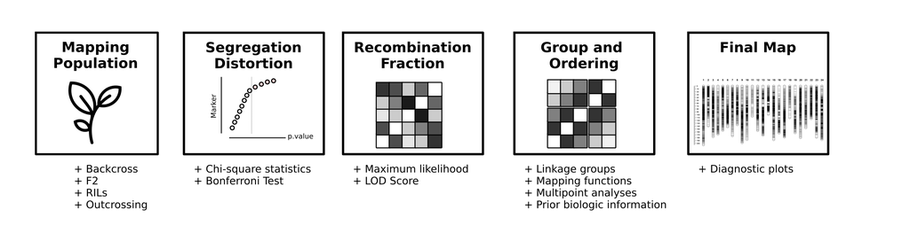

Main steps related to estimate a Linkage Map

## Mapping Population

The first essential step in linkage map construction is to develop a suitable mapping population. This population must consist of individuals derived from a known cross—commonly F2, backcross, recombinant inbred lines (RILs), or outcrossing full-sib populations. The choice of population type directly affects:

- The expected segregation ratios,
- The complexity of the analysis,

Once the population is established, all individuals (including the parents) must be genotyped using molecular markers such as SNPs, SSRs, or DArT markers. These markers are used to track the inheritance of alleles across the population.

After importing the data, the first analytical step is to test each marker for Mendelian segregation using a chi-square test. This helps identify markers that deviate from expected segregation ratios, which may indicate genotyping errors, selection, or other biological phenomena.

For the code below we will download a simulated example from the OneMap package. Some information:

- OneMap can accept different inputs
- In modern genotyping platforms, it is common to obtain high-density marker data, which often includes redundant markers—markers that are genetically identical or co-segregating. To address this redundancy, the functions `find_bins()` and create_`data_bins(`)` in OneMap are used to identify and collapse these redundant markers into representative bins, similar to how LD pruning is applied in population genetics to reduce marker redundancy. This binning process simplifies the dataset without losing informative recombination signals, making map construction faster and more robust. Note: In this example, no redundant markers were simulated, so binning is not necessary.

```r
library(onemap)
# Importing the data
setwd("/home/felipe/Dropbox (UFL)/classes/Molecular_Breeding/class1_linkageMapping")
mapmaker_example_bc <- read_onemap(inputfile="onemap_example_bc.raw")
```

```
##  Working...
##
##  --Read the following data:
##  Type of cross:           backcross
##  Number of individuals:   150
##  Number of markers:       70
##  Chromosome information:  no
##  Position information:    no
##  Number of traits:        1
##  Missing trait values:
##   Trait_1: 0
```

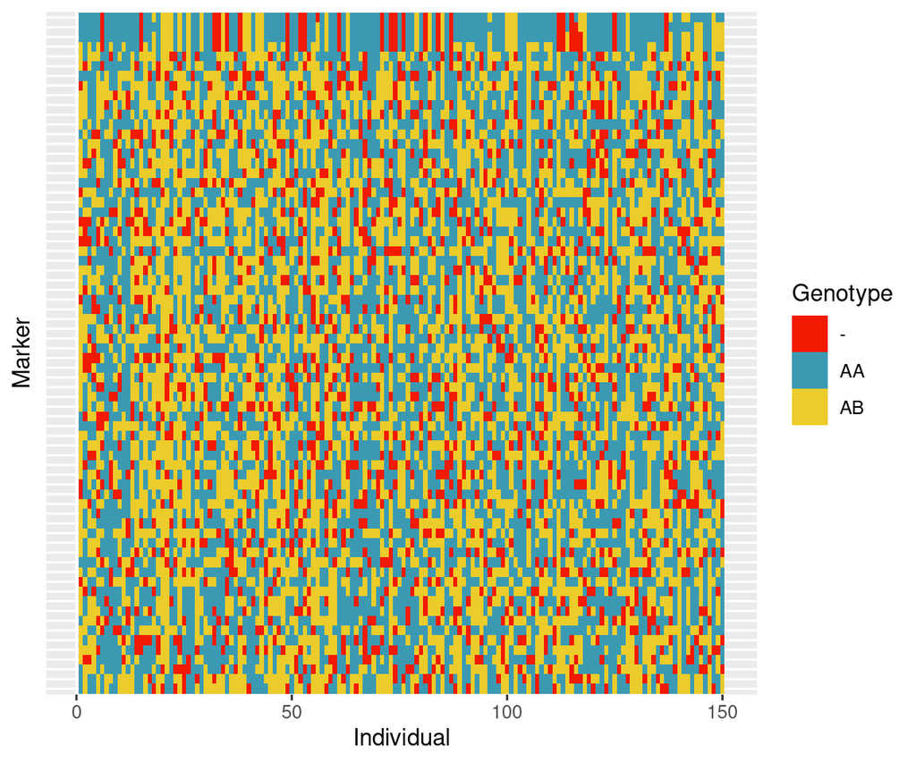

```r
plot(mapmaker_example_bc)
```

```r
# Find redundant markers
bins <- find_bins(mapmaker_example_bc, exact = FALSE)
bins_example <- create_data_bins(mapmaker_example_bc, bins)
bins_example
```

```
##   This is an object of class 'onemap'
##     Type of cross:      backcross
##     No. individuals:    150
##     No. markers:        70
##     CHROM information:  no
##     POS information:    no
##     Percent genotyped:  85
##
##     Segregation types:
##             AA : AB -->  70
##
##     No. traits:         1
##     Missing trait values:
##   Trait_1: 0
```

## Mendelian segregation distortion

In this example, we consider a backcross population consisting of 10 full-sib individuals genotyped at two codominant markers (Marker 1 and Marker 2). The genotypes were scored visually, simulating a gel image where bands represent alleles at different genomic loci. Since this is a backcross, we expect the Mendelian segregation ratio to be 1:1 (e.g., AA : Aa). By counting the observed genotypes for each marker, we can:

Visually inspect possible segregation distortion.

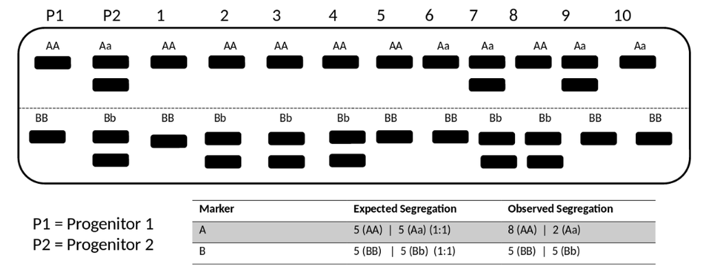

Example of gel image for 10 full-sib individuals genotyped at two codominant markers (Marker 1 and Marker 2)

```r
# Marker 1: 8 AA, 2 Aa
obs_marker1 <- c(8, 2)
exp_marker1 <- c(5, 5)

chisq_test_marker1 <- chisq.test(x = obs_marker1, p = c(0.5, 0.5))
print(chisq_test_marker1)
```

```
##
##  Chi-squared test for given probabilities
##
## data:  obs_marker1
## X-squared = 3.6, df = 1, p-value = 0.05778
```

```r
# Marker 2: 5 AA, 5 Aa
obs_marker2 <- c(5, 5)
exp_marker2 <- c(5, 5)

chisq_test_marker2 <- chisq.test(x = obs_marker2, p = c(0.5, 0.5))
print(chisq_test_marker2)
```

```
##
##  Chi-squared test for given probabilities
##
## data:  obs_marker2
## X-squared = 0, df = 1, p-value = 1
```

**Interpretation**

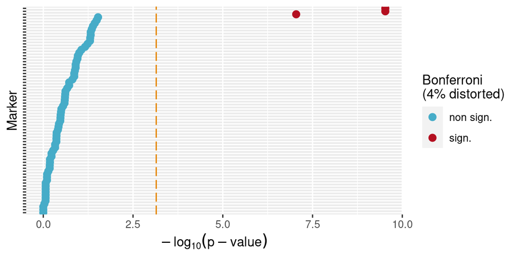

```r
# Segregation test
bc_test <- test_segregation(bins_example)
no_dist <- select_segreg(bc_test, distorted = FALSE, numbers = TRUE)
plot(bc_test)
```

## Two-Point Analysis and Likelihood in a Backcross

The next step in linkage map construction is called **two-point analysis**. This involves estimating the **recombination fraction (r)** between all pairs of markers. The equations used to calculate these values depend on the **type of mapping population**, such as backcross (BC), F2, or recombinant inbred lines (RILs). In a **backcross population**, the calculation is relatively straightforward. The recombination fraction represents the proportion of recombinant individuals among the total and is bounded between 0 and 0.5 (no linkage). For each pair of markers, we estimate **r** by maximizing the **likelihood function** under the assumption of Mendelian segregation.

The **likelihood function** for a single marker pair in a backcross is given by:

$$L(r) = (1 - r)^{n_{P}} \cdot r^{n_{R}}$$

Where:

- $r$ = recombination fraction (0 ≤ r ≤ 0.5)
- $n_P$ = number of **parental-type** individuals
- $n_R$ = number of **recombinant-type** individuals

This likelihood is maximized to estimate the most probable recombination fraction between the markers. To assess the **statistical significance** of linkage, we compute the **LOD score** (logarithm of the odds):

$$\text{LOD} = \log_{10} \left( \frac{L(\hat{r})}{L(0.5)} \right)$$

Where:

- $\hat{r}$ = estimated recombination fraction
- $L(0.5)$ = likelihood under the null hypothesis of no linkage

A LOD score ≥ 3 is typically considered strong evidence for linkage.

The final goal of two-point analysis is to generate a matrix of **pairwise recombination values and LOD scores**, which will be used to construct linkage groups and marker order, as illustrated in the heatmap below.

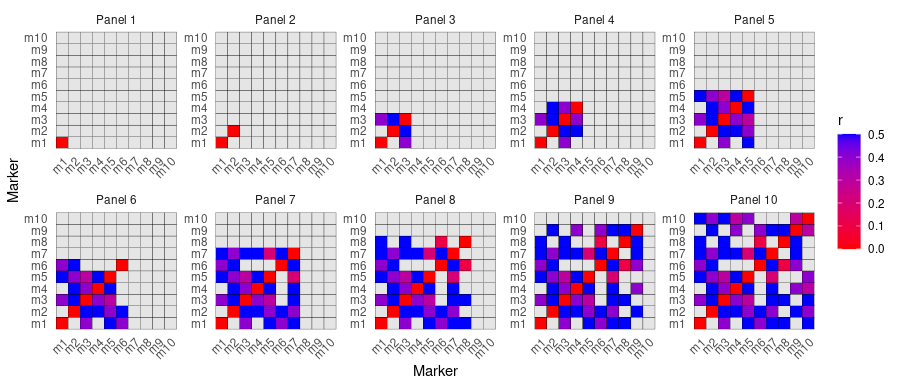

Example of sequencial analyses in BC

```r
library(onemap)
twopts_bc <-rf_2pts(bins_example, LOD = 3, max.rf = 0.5, verbose = TRUE)
```

```
## Computing 2415 recombination fractions ...
```

```r
print(twopts_bc, c("M1", "M2"))
```

```
##   Results of the 2-point analysis for markers: M1 and M2
##   Criteria: LOD =  3 , Maximum recombination fraction =  0.5
##
##          rf         LOD
##  0.03603604 25.93578305
```

Here we will start using some important functions in OneMap. The first one is the `make_seq`, this is the function that will create a sequence of markers based on an object. In the example below, we will take `all` the markers and plot the heatmap from the two point analyses as a single heatmap. For the next codes, we will start to separate it by linkage group.

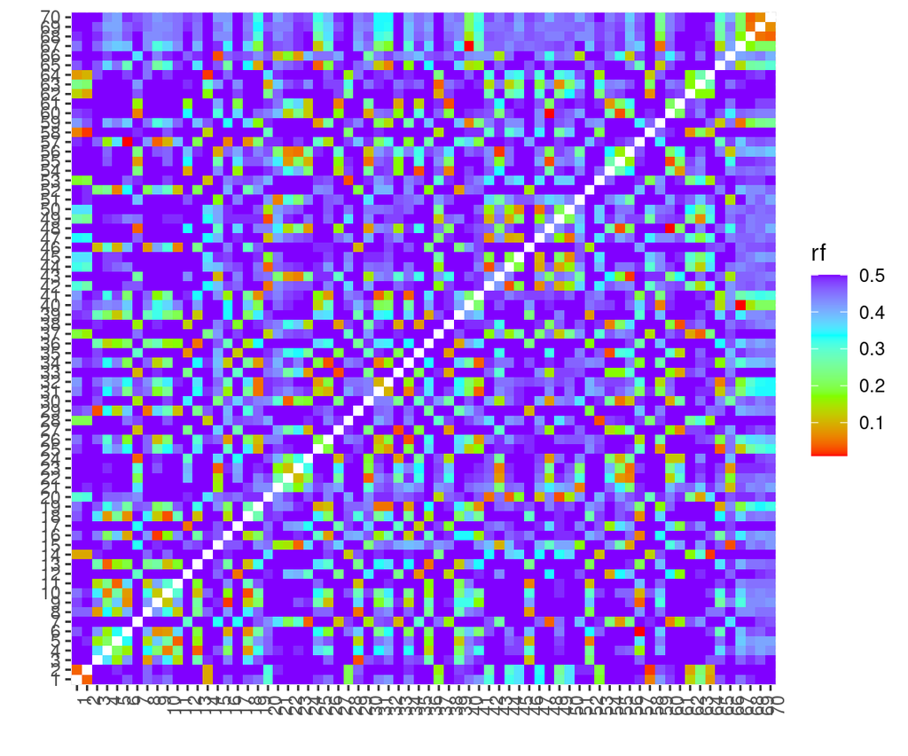

```r
all_mrks <- make_seq(twopts_bc, "all")
rf_graph_table(all_mrks)
```

## Linkage Groups and Ordering

In linkage mapping, markers are grouped into linkage groups based on their genetic associations. This can be done using either **heuristic methods** or **statistical methods**, depending on the dataset and the software used.

**Heuristic Method**

- If the recombination frequency ($r$) between two markers is **less than 0.5** **and** the **LOD score is greater than 3**,
- Then these two markers are considered to belong to the **same linkage group**.

**Statistical Method**

- Uses **clustering or grouping algorithms** (e.g., UPGMA) to assign markers into linkage groups.
- These methods are implemented in more recent linkage mapping software.
- They can incorporate **prior information**, such as the expected number of chromosomes, to improve accuracy.

```r
# Assigning markers to linkage groups
mark_no_dist <- make_seq(twopts_bc, c(no_dist))

# heuristic
LGs <- group(mark_no_dist, LOD=3, max.rf=0.5)
```

```
##    Selecting markers:
##    group    1
##     ................
##    group    2
##     ...........................
##    group    3
##     .....................
```

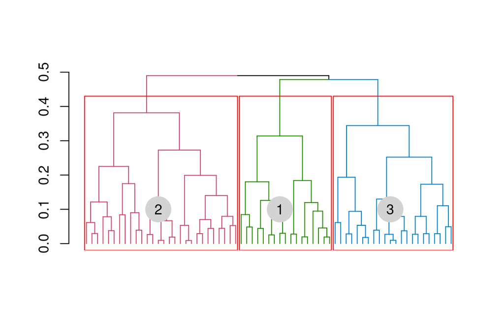

```r
# grouping
LGs_upgma <- group_upgma(mark_no_dist, expected.groups = 3, inter = F)
plot(LGs_upgma)
```

### Linkage Group 1

- Use the `make_seq` to separate the LG1 from the rest
- Start ordering using two different approaches:
  - `mds_onemap`
  - `order_seq` (multipoint analyses)
- Diagnostic using the `rf_graph_table` function

```r
library(gridExtra)
# No-multipoint analyses
LG1 <- make_seq(LGs, 1)
LG1_mds_bc <- mds_onemap(input.seq = LG1, hmm = F)
```

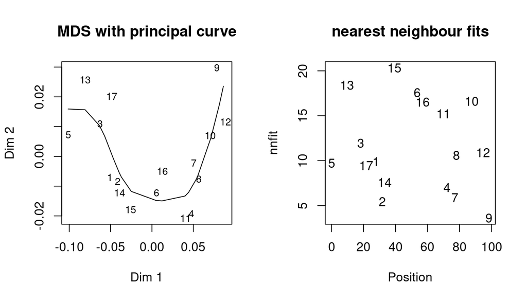

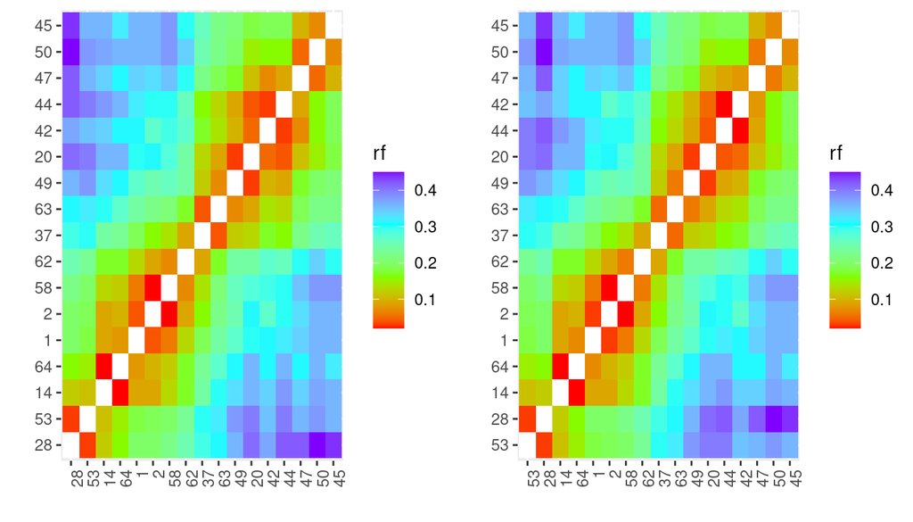

```r
# HMM version
LG1_bc_ord <- order_seq(input.seq = LG1, n.init = 5,
                        subset.search = "twopt",
                        twopt.alg = "rcd", THRES = 3,
                        touchdown = TRUE)
LG1_bc_final <- make_seq(LG1_bc_ord, "force")

# Comparing the results
p2=rf_graph_table(LG1_mds_bc)
p3=rf_graph_table(LG1_bc_final)
grid.arrange(p2,p3, ncol=2)
```

### Linkage Group 2

```r
library(gridExtra)
# No-multipoint analyses
LG2 <- make_seq(LGs, 2)
LG2_mds_bc <- mds_onemap(input.seq = LG2, hmm = F)
```

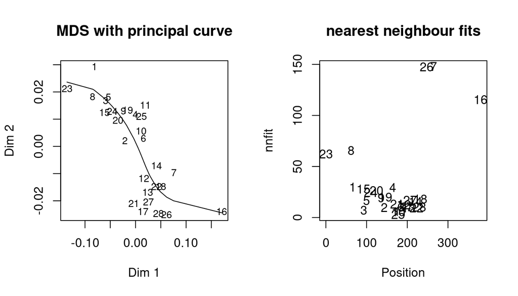

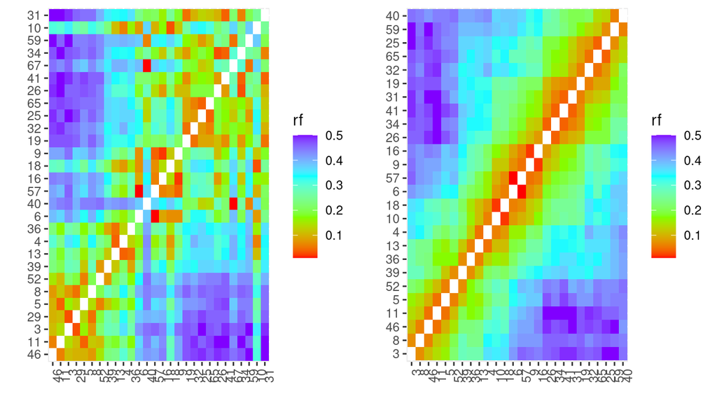

```r
# HMM version
LG2_bc_ord <- order_seq(input.seq = LG2, n.init = 5,
                        subset.search = "twopt",
                        twopt.alg = "rcd", THRES = 3,
                        touchdown = TRUE)
LG2_bc_final <- make_seq(LG2_bc_ord)

# Comparing the results
p2=rf_graph_table(LG2_mds_bc)
p3=rf_graph_table(LG2_bc_final)
grid.arrange(p2,p3,ncol=2)
```

### Linkage Group 3

```r
library(gridExtra)
# No-multipoint analyses
LG3 <- make_seq(LGs, 3)
LG3_mds_bc <- mds_onemap(input.seq = LG3, hmm = F)
```

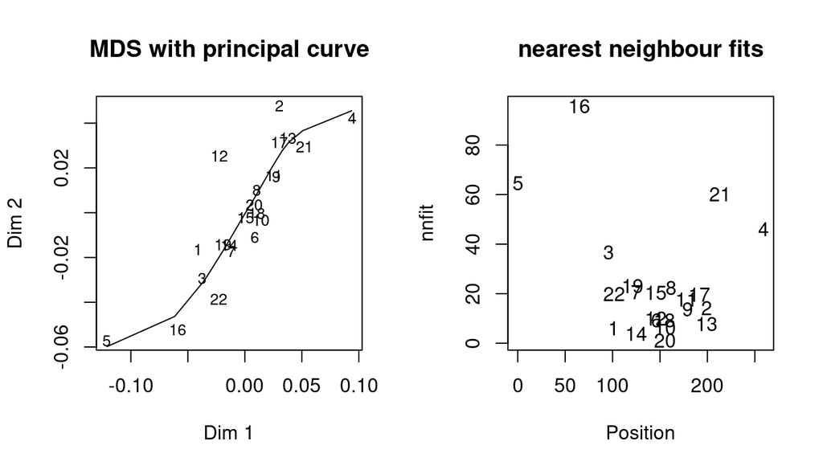

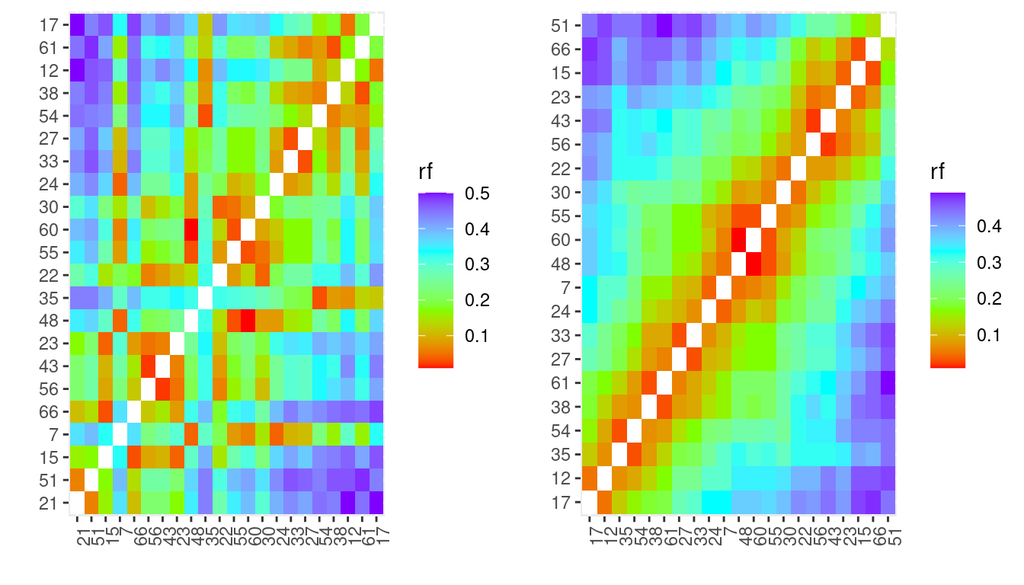

```r
# HMM version
LG3_bc_ord <- order_seq(input.seq = LG3, n.init = 5,
                        subset.search = "twopt",
                        twopt.alg = "rcd", THRES = 3,
                        touchdown = TRUE)
LG3_bc_final <- make_seq(LG3_bc_ord)

# Comparing the results
p2=rf_graph_table(LG3_mds_bc)
p3=rf_graph_table(LG3_bc_final)
grid.arrange(p2,p3, ncol=2)
```

## Final Map

Check list:

- **Marker Order Consistency:** if we have reference genomes available, the order of markers should be biologically consistent. Also, if different algorithms (e.g. RECORD, Seriation, ripple) produce similar marker orders, that increases confidence in the map
- **Visual Inspection of Heatmaps:** heatmaps of recombination fractions and LOD scores should show a clear diagonal pattern in each linkage group.
- **Inflate map distances:** check for long gaps (> 10-20cM) and amount of missing data (or genotyping errors), it can inflate the map (> 150-200 cM is a red flag).

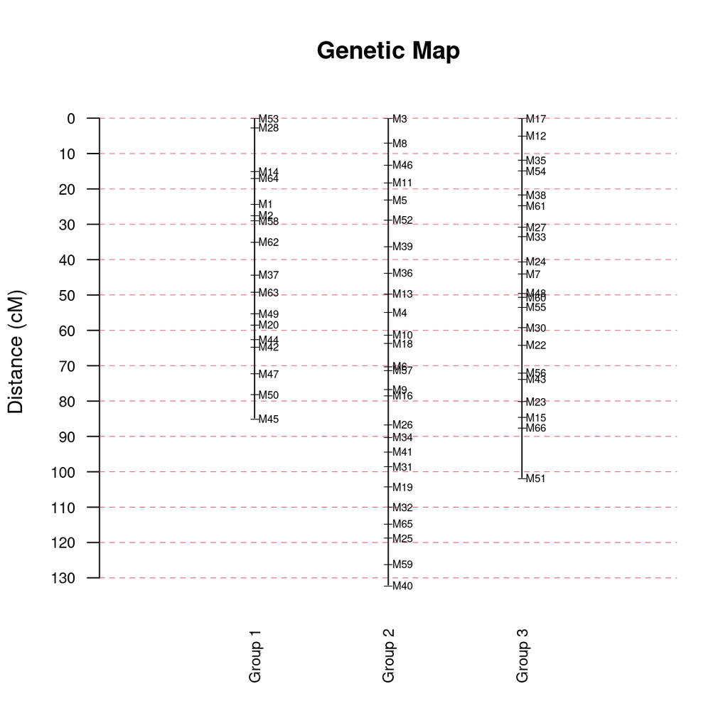

```r
maps_list <- list(LG1_bc_final, LG2_bc_final,LG3_bc_final)
draw_map(maps_list, names = TRUE, grid = TRUE, cex.mrk = 0.7)
```

# Impact of population size on map estimation

We simulated a F2 population with only SNP markers and different population sizes, using the [PedigreeSim software](https://www.wur.nl/en/show/Software-PedigreeSim.htm). In the sequence, we will implement the following general pipeline for linkage map construction.

- Marker and Individual Filtering
  - Bioinformatics pipeline (reading depth, missing data, maf, genomic mapping etc)
  - Contaminant individuals (usually detected with paternity test or clustering analysis as PCA and UPGMA). SSR to detect paternity BEFORE genotyping
  - Segregation distortion (Chi-square test markers follow expected segregation ratio)
  - During the map construction (not grouped, odd pattern, mapping inflation etc)
- Build pairwise recombination fraction matrix (`rf_2pts`)
- Group (clustering analysis, threshold on rf) (`group` and `make_seq`)
- Order (rcd, ug, seriation, record, mds, genomic order) (`order_seq`)
- Estimate map (two-point or multipoint approaches) (`map`)
- Evaluation and redo 1 to 5

## Steps related to linkage mapping

- Simulated date (n=100 ind)
- No problems with map estimation
- Toy example

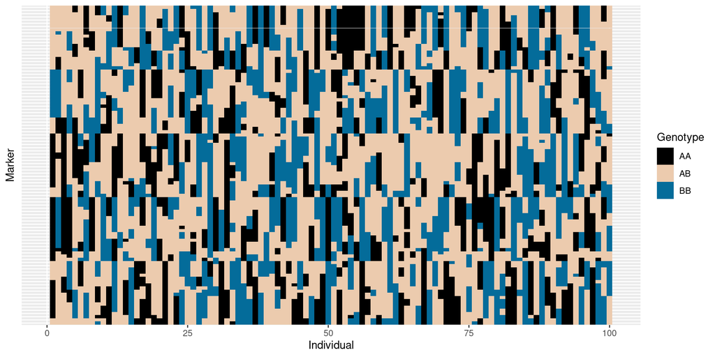

```r
setwd("/home/felipe/UFL Dropbox/Luis Ferrao/classes/Molecular_Breeding/2025/OLD - F21 Mol Markers Breeding (1)/Week 3/HOS6236_Mapping_Practice")

## Reading your data file
#dat <- read_onemap(inputfile = "raw_1000ind.txt")
#dat <- read_onemap(inputfile = "raw_300ind.txt")
dat <- read_onemap(inputfile = "raw_100ind.txt")
#dat <- read_onemap(inputfile = "raw_50ind.txt")
#dat <- read_onemap(inputfile = "raw_20ind.txt")


## Diagonist plots
plot(dat,all = FALSE)
```

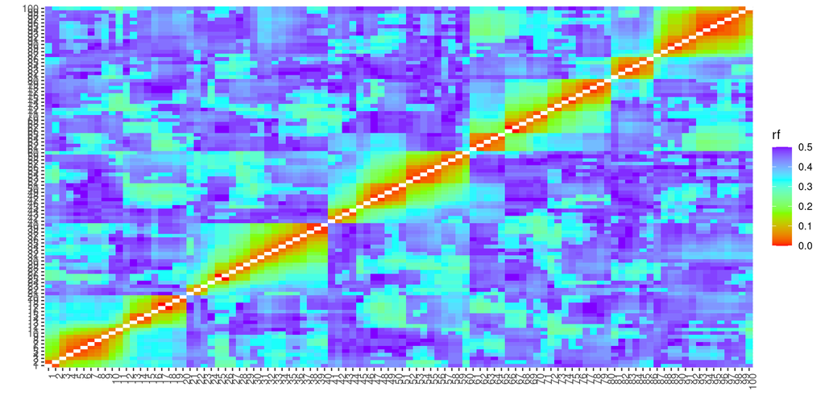

```r
## Chi-square test for segregation distortion
segreg_test <- test_segregation(dat)
select_segreg(segreg_test, distorted = TRUE)

## Getting suggested LOD to use as threshold for (bonferroni correction)
LOD_sug <- suggest_lod(dat)

## Computing 2pts recombination fraction mat
twopts <- rf_2pts(dat, LOD = LOD_sug, max.rf = 0.5)
mark_no_dist <- make_seq(twopts, "all")
all_mrks <- make_seq(twopts,"all")
all_mrks <- map(all_mrks)
rf_graph_table(all_mrks)
```

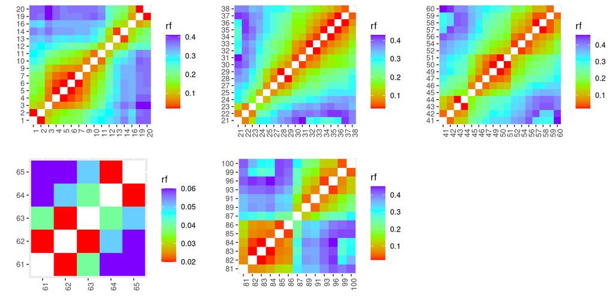

```r
## Grouping
set_map_fun(type = "haldane")
LGs <- group(mark_no_dist)

## LG1 Ordering and Multipoint-estimation
LG1 <- make_seq(LGs,1)
LG1_order <- order_seq(LG1,tol=0.01)
LG1_seq <- make_seq(LG1_order)
LG1_final <-  map(LG1_seq)
p1=rf_graph_table(LG1_final,inter=FALSE)

## LG2 Ordering
LG2 <- make_seq(LGs, 2)
LG2_order <- order_seq(LG2,tol=0.01)
LG2_seq <- make_seq(LG2_order)
LG2_final <-  map(LG2_seq)
p2 = rf_graph_table(LG2_final,inter=FALSE)

## LG3 Ordering
LG3 <- make_seq(LGs, 3)
LG3_order <- order_seq(LG3,tol=0.01)
LG3_seq <- make_seq(LG3_order)
LG3_final <-  map(LG3_seq)
p3 = rf_graph_table(LG3_final,inter=FALSE)

## LG4 Ordering
LG4 <- make_seq(LGs, 4)
LG4_order <- order_seq(LG4,tol=0.01)
LG4_seq <- make_seq(LG4_order)
LG4_final <-  map(LG4_seq)
p4 = rf_graph_table(LG4_final,inter=FALSE)

## LG5 Ordering
LG5 <- make_seq(LGs, 5)
LG5_order <- order_seq(LG5,tol=0.01)
LG5_seq <- make_seq(LG5_order)
LG5_final <-  map(LG5_seq)
p5 = rf_graph_table(LG5_final,inter=FALSE)

grid.arrange(p1,p2,p3,p4,p5, ncol=3)
```

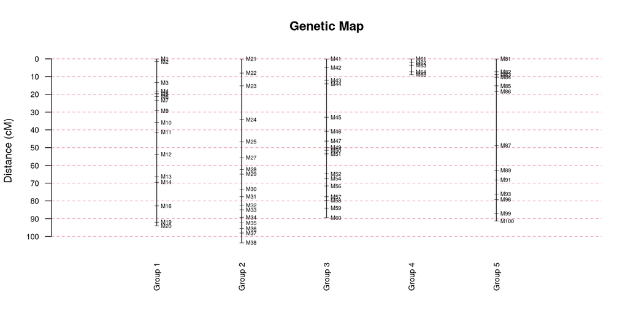

```r
## Map drawing and visualization
MAP1 <- list(LG1_final, LG2_final,LG3_final,LG4_final,LG5_final)
draw_map(MAP1,names = TRUE, grid = TRUE, cex.mrk = 0.7)
```

## Loop to create maps with different population size

- Map 1: 100 ind (original map)
- Map 2: 300 ind
- Map 3: 1000 ind
- Map 4: 50 ind

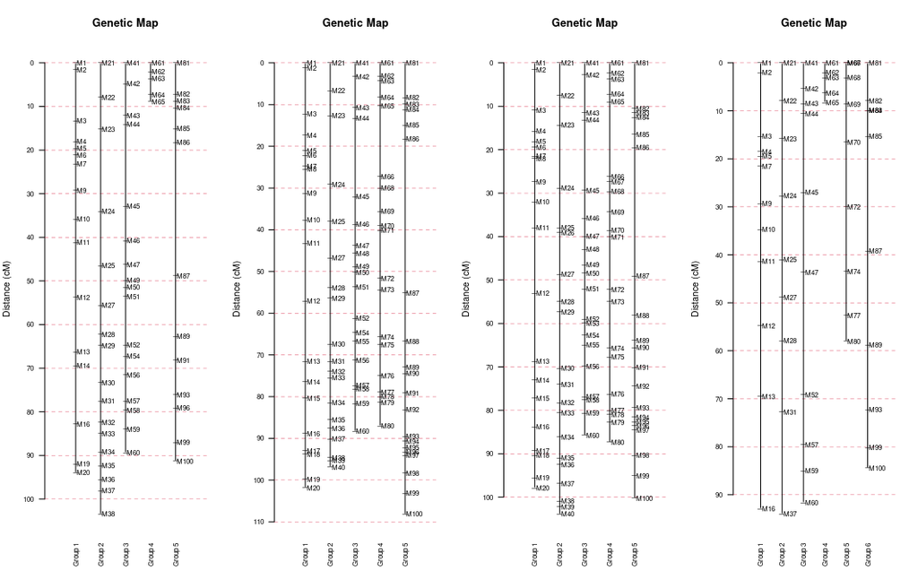

```r
MAPs <- vector("list",4)
MAPs[[1]] <- MAP1

for(i in 2:4){
    if(i==2)
        dat <- read_onemap(inputfile = "raw_300ind.txt")
    if(i==3)
        dat <- read_onemap(inputfile = "raw_1000ind.txt")
    if(i==4)
        dat <- read_onemap(inputfile = "raw_50ind.txt")
    segreg_test <- test_segregation(dat)
    select_segreg(segreg_test, distorted = TRUE)
    LOD_sug <- suggest_lod(dat)
    twopts <- rf_2pts(dat, LOD = LOD_sug, max.rf = 0.5)
    mark_no_dist <- make_seq(twopts, "all")
    all_mrks <- make_seq(twopts,"all")
    all_mrks <- map(all_mrks)
    LGs <- group(mark_no_dist)
    LGs_final <- vector("list",max(LGs$groups))
    for(lg_i in 1:max(LGs$groups)){
        LG <- make_seq(LGs,lg_i)
        LG_order <- order_seq(LG,tol=0.01)
        LG_seq <- make_seq(LG_order)
        LGs_final[[lg_i]] <-  map(LG_seq)
    }
    MAPs[[i]] <- LGs_final
}


draw_map(MAPs[[1]],names=TRUE, grid = TRUE, cex.mrk=1)
draw_map(MAPs[[2]],names=TRUE, grid = TRUE, cex.mrk=1)
draw_map(MAPs[[3]],names=TRUE, grid = TRUE, cex.mrk=1)
draw_map(MAPs[[4]],names=TRUE, grid = TRUE, cex.mrk=1)

## Or all together:

par(mfrow=c(1,4))
for(i in 1:4)(draw_map(MAPs[[i]],names = TRUE, grid = TRUE, cex.mrk = 1))
```

**Evolution of the maps**

In the animation below, check how the map is chainging depending on the population size. Major modification:

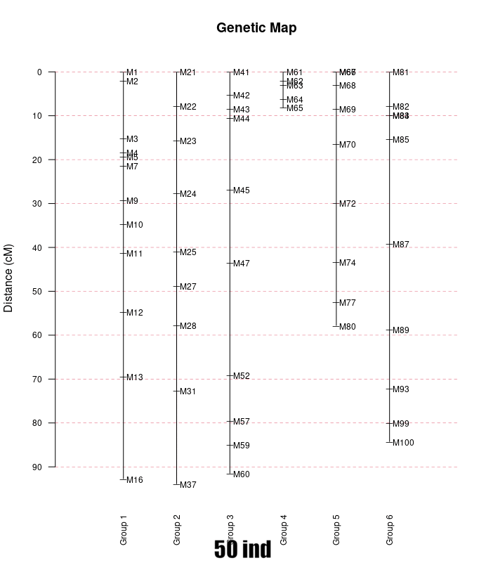

Different population size

- Number of markers included in the final map (LG 4 is a good example)
- Final number of linkage groups.
- Gaps between markers within the linkage groups (density)

# Including some missing data

- We included random missing data (40%) in the data set with 300 ind.
- Check the size of the linkage groups
- Focus on the linkage group 5

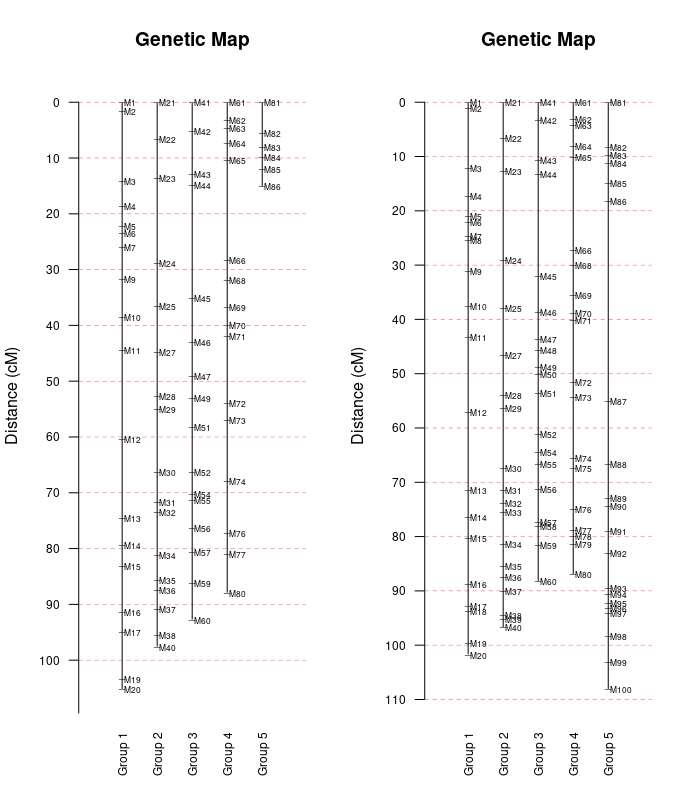

Map1(300 ind and 40% of missing data) and Map2 (300 ind and no missing data)

```r
setwd("/home/felipe/UFL Dropbox/Luis Ferrao/classes/Molecular_Breeding/2025/OLD - F21 Mol Markers Breeding (1)/Week 3/HOS6236_Mapping_Practice")

## Reading your data file
dat <- read_onemap(inputfile = "raw_300ind_missing40.txt")

## Diagonist plots
plot(dat,all = FALSE)

## Chi-square test for segregation distortion
segreg_test <- test_segregation(dat)
select_segreg(segreg_test, distorted = TRUE)

## Getting suggested LOD to use as threshold for (bonferroni correction)
LOD_sug <- suggest_lod(dat)

## Computing 2pts recombination fraction mat
twopts <- rf_2pts(dat, LOD = LOD_sug, max.rf = 0.5)
mark_no_dist <- make_seq(twopts, "all")
all_mrks <- make_seq(twopts,"all")
all_mrks <- map(all_mrks)
rf_graph_table(all_mrks)

## Grouping
set_map_fun(type = "haldane")
LGs <- group(mark_no_dist)

## LG1 Ordering and Multipoint-estimation
LG1 <- make_seq(LGs,1)
LG1_order <- order_seq(LG1,tol=0.01)
LG1_seq <- make_seq(LG1_order)
LG1_final <-  map(LG1_seq)
p1=rf_graph_table(LG1_final,inter=FALSE)

## LG2 Ordering
LG2 <- make_seq(LGs, 2)
LG2_order <- order_seq(LG2,tol=0.01)
LG2_seq <- make_seq(LG2_order)
LG2_final <-  map(LG2_seq)
p2 = rf_graph_table(LG2_final,inter=FALSE)

## LG3 Ordering
LG3 <- make_seq(LGs, 3)
LG3_order <- order_seq(LG3,tol=0.01)
LG3_seq <- make_seq(LG3_order)
LG3_final <-  map(LG3_seq)
p3 = rf_graph_table(LG3_final,inter=FALSE)

## LG4 Ordering
LG4 <- make_seq(LGs, 4)
LG4_order <- order_seq(LG4,tol=0.01)
LG4_seq <- make_seq(LG4_order)
LG4_final <-  map(LG4_seq)
p4 = rf_graph_table(LG4_final,inter=FALSE)

## LG5 Ordering
LG5 <- make_seq(LGs, 5)
LG5_order <- order_seq(LG5,tol=0.01)
LG5_seq <- make_seq(LG5_order)
LG5_final <-  map(LG5_seq)
p5 = rf_graph_table(LG5_final,inter=FALSE)

grid.arrange(p1,p2,p3,p4,p5, ncol=3)

## Map drawing and visualization
MAP1 <- list(LG1_final, LG2_final,LG3_final,LG4_final,LG5_final)
draw_map(MAP1,names = TRUE, grid = TRUE, cex.mrk = 0.7)
```

# What we did not cover in this tutorial?

- The use of priori information from reference genomes
- More details about HMM and multipoint analyses
- Other types of population mapping, including outcrossing species
- Polyploid analyses

# Conclusion

Despite advances in sequencing technologies and reference genome assemblies, linkage mapping remains a critical tool for uncovering the genetic architecture of traits, validating genome assemblies, infer haplotypes, and guiding marker-assisted selection in breeding programs.